# Statistical and Machine Learning

Lab1: Model Assessment  
Evaluation, Cross-validation, and Bootstrap

Tsai, Dai-Rong

## Dataset

> *Pima Indians Diabetes Database*

```r
# Set random seed
set.seed(999)

# Packages
library(caret) # for knn3, confusionMatrix
library(pROC) # for roc, auc

# Data
data(PimaIndiansDiabetes, package = "mlbench")
```

- Response
  - `diabetes`: test for diabetes (`neg` / `pos`)
- Predictors
  - `pregnant`: Number of times pregnant
  - `glucose`: Plasma glucose concentration (glucose tolerance test)
  - `pressure`: Diastolic blood pressure (mmHg)
  - `triceps`: Triceps skin fold thickness (mm)
  - `insulin`: 2-hour serum insulin ($\mu$U/ml)
  - `mass`: Body mass index (weight in kg/$\text{(height in m)}^2$)
  - `pedigree`: Diabetes pedigree function
  - `age`: Age (years)
- Preview
- Data Structure

```r
dim(PimaIndiansDiabetes)
```

```
[1] 768   9
```

```r
head(PimaIndiansDiabetes)
```

```
  pregnant glucose pressure triceps insulin mass pedigree age diabetes
1        6     148       72      35       0 33.6    0.627  50      pos
2        1      85       66      29       0 26.6    0.351  31      neg
3        8     183       64       0       0 23.3    0.672  32      pos
4        1      89       66      23      94 28.1    0.167  21      neg
5        0     137       40      35     168 43.1    2.288  33      pos
6        5     116       74       0       0 25.6    0.201  30      neg
```

```r
str(PimaIndiansDiabetes)
```

```
'data.frame':   768 obs. of  9 variables:
 $ pregnant: num  6 1 8 1 0 5 3 10 2 8 ...
 $ glucose : num  148 85 183 89 137 116 78 115 197 125 ...
 $ pressure: num  72 66 64 66 40 74 50 0 70 96 ...
 $ triceps : num  35 29 0 23 35 0 32 0 45 0 ...
 $ insulin : num  0 0 0 94 168 0 88 0 543 0 ...
 $ mass    : num  33.6 26.6 23.3 28.1 43.1 25.6 31 35.3 30.5 0 ...
 $ pedigree: num  0.627 0.351 0.672 0.167 2.288 ...
 $ age     : num  50 31 32 21 33 30 26 29 53 54 ...
 $ diabetes: Factor w/ 2 levels "neg","pos": 2 1 2 1 2 1 2 1 2 2 ...
```

## Tasks

1. Split data into 80% training set and 20% test set.
2. Train a $k$-Nearest Neighbour (`k-NN`) classifier to predict whether individuals in the test dataset have diabetes.
3. The number of neighbours `k` is determined using
   - 10-fold Cross-validation
   - Bootstrap

## Create Training/Testing Partitions

- Split data into 80% training set and 20% test set

```r
nr <- nrow(PimaIndiansDiabetes)
train.id <- sample(nr, nr * 0.8)

training <- PimaIndiansDiabetes[train.id, ]
testing <- PimaIndiansDiabetes[-train.id, ]
```

- Check dimension

```r
dim(training)
```

```
[1] 614   9
```

```r
dim(testing)
```

```
[1] 154   9
```

## k-Fold Cross-Validation

```r
n.folds <- 10
foldid <- sample(cut(1:nrow(training), n.folds, labels = FALSE))
table(foldid)
```

```
foldid
 1  2  3  4  5  6  7  8  9 10
62 61 61 62 61 61 62 61 61 62
```

#### (Step 1.) Predict the 1st fold using the 2nd to 10th folds as training set.

```r
true.label <- training$diabetes[foldid == 1]
knn.mod <- knn3(diabetes ~ ., data = training[foldid != 1, ], k = 3)
knn.pred <- predict(knn.mod, newdata = training[foldid == 1, ], type = "class")
knn.pred
```

```
 [1] neg pos pos pos neg neg neg pos pos neg pos pos pos neg neg neg pos pos neg neg neg pos pos pos
[25] pos neg neg neg neg neg pos neg pos neg neg neg neg neg pos neg neg neg pos neg pos neg neg pos
[49] neg neg neg neg neg pos pos neg neg neg pos pos neg pos
Levels: neg pos
```

**Arguments**

- `type`
  - `"prob"` (default) : return the proportion of the votes for the winning class.
  - `"class"`: return the predicted class.
- Confusion Matrix

```r
table(Reality = true.label, Prediction = knn.pred)
```

```
       Prediction
Reality neg pos
    neg  30  13
    pos   7  12
```

- Accuracy

```r
mean(true.label == knn.pred)
```

```
[1] 0.677
```

#### (Step 2.) Iterate across all the 10 folds with `k` from 3 to 21.

```r
k.grid <- seq(3, 21, by = 2)

acc.cv <- sapply(k.grid, \(k) {
  sapply(1:n.folds, \(x) {
      ## Put codes from (Step 1) here
  })
})
```

#### (Step 2.) Iterate across all the 10 folds with `k` from 3 to 21.

```r
k.grid <- seq(3, 21, by = 2)

acc.cv <- sapply(k.grid, \(k) {
  sapply(1:n.folds, \(x) {
    true.label <- training$diabetes[foldid == x]
    knn.mod <- knn3(diabetes ~ ., data = training[foldid != x, ], k = k)
    knn.pred <- predict(knn.mod, newdata = training[foldid == x, ], type = "class")
    return(mean(true.label == knn.pred))
  })
})

dimnames(acc.cv) <- list(paste('fold =', 1:n.folds), paste('k =', k.grid))
```

#### (Step 2.) Iterate across all the 10 folds with `k` from 3 to 21.

```r
k.grid <- seq(3, 21, by = 2)

acc.cv <- sapply(k.grid, \(k) {
  sapply(1:n.folds, \(x) {
    true.label <- training$diabetes[foldid == x]
    knn.mod <- knn3(diabetes ~ ., data = training[foldid != x, ], k = k)
    knn.pred <- predict(knn.mod, newdata = training[foldid == x, ], type = "class")
    return(mean(true.label == knn.pred))
  })
})

dimnames(acc.cv) <- list(paste('fold =', 1:n.folds), paste('k =', k.grid))
```

```r
acc.cv
```

```
          k = 3 k = 5 k = 7 k = 9 k = 11 k = 13 k = 15 k = 17 k = 19 k = 21
fold = 1  0.677 0.677 0.677 0.694  0.694  0.710  0.726  0.710  0.726  0.726
fold = 2  0.721 0.705 0.721 0.721  0.721  0.705  0.738  0.787  0.738  0.705
fold = 3  0.721 0.721 0.689 0.705  0.705  0.705  0.705  0.705  0.721  0.738
fold = 4  0.742 0.758 0.790 0.790  0.790  0.790  0.774  0.758  0.758  0.774
fold = 5  0.689 0.738 0.754 0.738  0.770  0.770  0.770  0.754  0.770  0.770
fold = 6  0.672 0.672 0.689 0.705  0.689  0.738  0.754  0.721  0.721  0.721
fold = 7  0.726 0.742 0.742 0.774  0.790  0.806  0.806  0.806  0.790  0.790
fold = 8  0.721 0.721 0.754 0.770  0.770  0.754  0.836  0.721  0.721  0.754
fold = 9  0.705 0.672 0.738 0.738  0.738  0.738  0.705  0.721  0.721  0.721
fold = 10 0.742 0.774 0.774 0.726  0.726  0.726  0.742  0.726  0.694  0.694
```

#### (Step 3.) For each `k`, calculate the average accuracy of the 10 folds, and pick the maximum as the final model.

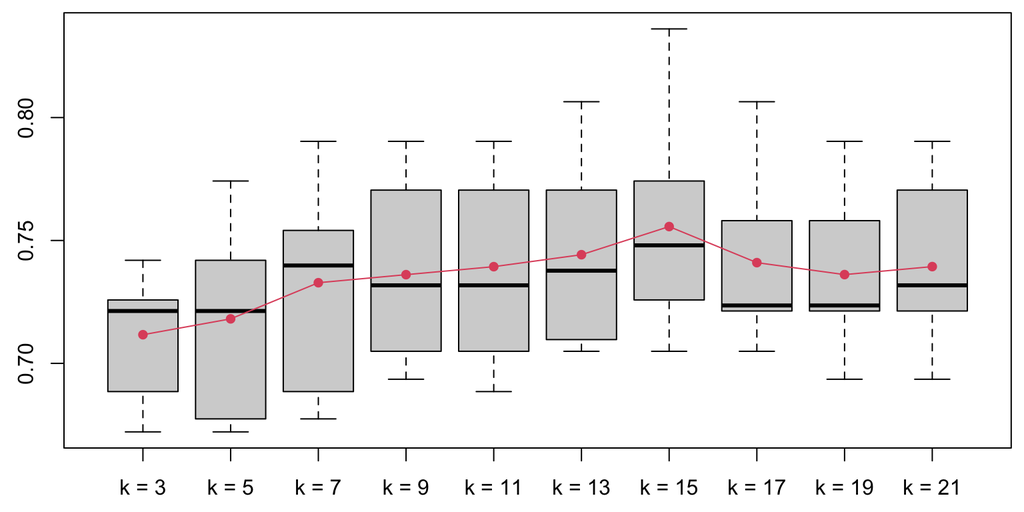

```r
boxplot(acc.cv)
points(1:ncol(acc.cv), colMeans(acc.cv), col = 2, pch = 16, type = 'o')
```

- Final model:

```r
(k.optim.cv <- k.grid[which.max(colMeans(acc.cv))])
```

```
[1] 15
```

## Bootstrap

#### (Step 1.) Randomly draw 1 dataset *with replacement* from the training data and each sample has the *same size* as the original training set.

```r
boot.id <- sample(nrow(training), nrow(training), replace = TRUE)
true.label <- training$diabetes[-boot.id]
```

- Refit the model and examine the behavior of the fit.

```r
knn.mod <- knn3(diabetes ~ ., data = training[boot.id, ], k = 3)
knn.pred <- predict(knn.mod, newdata = training[-boot.id, ], type = "class")
```

- Confusion Matrix

```r
table(Reality = true.label, Prediction = knn.pred)
```

```
       Prediction
Reality neg pos
    neg 122  24
    pos  49  38
```

- Accuracy

```r
mean(true.label == knn.pred)
```

```
[1] 0.687
```

#### (Step 2.) Repeat `B`=1,000 times with `k` from 3 to 21.

```r
B <- 1000
k.grid <- seq(3, 21, by = 2)

acc.boot <- sapply(k.grid, \(k) {
  replicate(B, {
    ## Put codes from (Step 1) here
  })
})
```

#### (Step 2.) Repeat `B`=1,000 times with `k` from 3 to 21.

```r
B <- 1000
k.grid <- seq(3, 21, by = 2)

acc.boot <- sapply(k.grid, \(k) {
  replicate(B, {
    boot.id <- sample(nrow(training), nrow(training), replace = TRUE)
    true.label <- training$diabetes[-boot.id]
    knn.mod <- knn3(diabetes ~ ., data = training[boot.id, ], k = k)
    knn.pred <- predict(knn.mod, newdata = training[-boot.id, ], type = "class")
    return(mean(true.label == knn.pred))
  })
})

dimnames(acc.boot) <- list(paste('Bootstrap =', 1:B), paste('k =', k.grid))
```

#### (Step 2.) Repeat `B`=1,000 times with `k` from 3 to 21.

```r
B <- 1000
k.grid <- seq(3, 21, by = 2)

acc.boot <- sapply(k.grid, \(k) {
  replicate(B, {
    boot.id <- sample(nrow(training), nrow(training), replace = TRUE)
    true.label <- training$diabetes[-boot.id]
    knn.mod <- knn3(diabetes ~ ., data = training[boot.id, ], k = k)
    knn.pred <- predict(knn.mod, newdata = training[-boot.id, ], type = "class")
    return(mean(true.label == knn.pred))
  })
})

dimnames(acc.boot) <- list(paste('Bootstrap =', 1:B), paste('k =', k.grid))
```

```r
head(acc.boot)
```

```
              k = 3 k = 5 k = 7 k = 9 k = 11 k = 13 k = 15 k = 17 k = 19 k = 21
Bootstrap = 1 0.698 0.738 0.682 0.698  0.704  0.709  0.698  0.740  0.701  0.722
Bootstrap = 2 0.634 0.693 0.733 0.710  0.755  0.716  0.688  0.687  0.717  0.745
Bootstrap = 3 0.699 0.704 0.702 0.708  0.728  0.734  0.709  0.761  0.723  0.715
Bootstrap = 4 0.679 0.674 0.693 0.728  0.712  0.728  0.746  0.726  0.724  0.716
Bootstrap = 5 0.624 0.673 0.670 0.675  0.707  0.720  0.696  0.710  0.728  0.758
Bootstrap = 6 0.688 0.635 0.702 0.731  0.744  0.775  0.740  0.674  0.743  0.744
```

```r
tail(acc.boot)
```

```
                 k = 3 k = 5 k = 7 k = 9 k = 11 k = 13 k = 15 k = 17 k = 19 k = 21
Bootstrap = 995  0.637 0.712 0.735 0.716  0.731  0.713  0.685  0.704  0.732  0.714
Bootstrap = 996  0.677 0.722 0.671 0.713  0.774  0.730  0.725  0.651  0.664  0.749
Bootstrap = 997  0.682 0.649 0.738 0.686  0.748  0.659  0.725  0.711  0.710  0.692
Bootstrap = 998  0.698 0.693 0.646 0.700  0.681  0.731  0.717  0.743  0.724  0.710
Bootstrap = 999  0.658 0.636 0.716 0.701  0.724  0.642  0.734  0.741  0.768  0.696
Bootstrap = 1000 0.644 0.667 0.640 0.686  0.671  0.681  0.741  0.716  0.737  0.685
```

#### (Step 3.) For each `k`, calculate the average accuracy of the 1000 bootstrap samples, and pick the maximum as the final model.

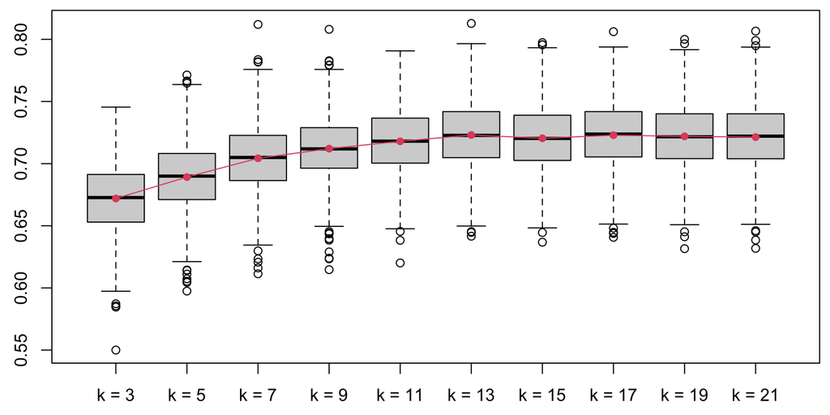

```r
boxplot(acc.boot)
points(1:ncol(acc.boot), colMeans(acc.boot), col = 2, pch = 16, type = 'o')
```

- Final model:

```r
(k.optim.boot <- k.grid[which.max(colMeans(acc.boot))])
```

```
[1] 13
```

## Predictions for the test dataset

- Model 1 (by Cross-validation)

```r
knn.mod.cv <- knn3(diabetes ~ ., data = training, k = k.optim.cv)
```

- Model 2 (by Bootstrap)

```r
knn.mod.boot <- knn3(diabetes ~ ., data = training, k = k.optim.boot)
```

- Confusion Matrix
- Model 1
- Model 2

```r
knn.pred.cv <- predict(knn.mod.cv, newdata = testing, type = "class")
confusionMatrix(knn.pred.cv, testing$diabetes, positive = "pos", mode = "everything")
```

```
Confusion Matrix and Statistics

          Reference
Prediction neg pos
       neg  95  24
       pos  15  20

               Accuracy : 0.747
                 95% CI : (0.67, 0.813)
    No Information Rate : 0.714
    P-Value [Acc > NIR] : 0.212

                  Kappa : 0.339

 Mcnemar's Test P-Value : 0.200

            Sensitivity : 0.455
            Specificity : 0.864
         Pos Pred Value : 0.571
         Neg Pred Value : 0.798
              Precision : 0.571
                 Recall : 0.455
                     F1 : 0.506
             Prevalence : 0.286
         Detection Rate : 0.130
   Detection Prevalence : 0.227
      Balanced Accuracy : 0.659

       'Positive' Class : pos
```

```r
knn.pred.boot <- predict(knn.mod.boot, newdata = testing, type = "class")
confusionMatrix(knn.pred.boot, testing$diabetes, positive = "pos", mode = "everything")
```

```
Confusion Matrix and Statistics

          Reference
Prediction neg pos
       neg  96  23
       pos  14  21

               Accuracy : 0.76
                 95% CI : (0.684, 0.825)
    No Information Rate : 0.714
    P-Value [Acc > NIR] : 0.122

                  Kappa : 0.373

 Mcnemar's Test P-Value : 0.188

            Sensitivity : 0.477
            Specificity : 0.873
         Pos Pred Value : 0.600
         Neg Pred Value : 0.807
              Precision : 0.600
                 Recall : 0.477
                     F1 : 0.532
             Prevalence : 0.286
         Detection Rate : 0.136
   Detection Prevalence : 0.227
      Balanced Accuracy : 0.675

       'Positive' Class : pos
```

- ROC Curve

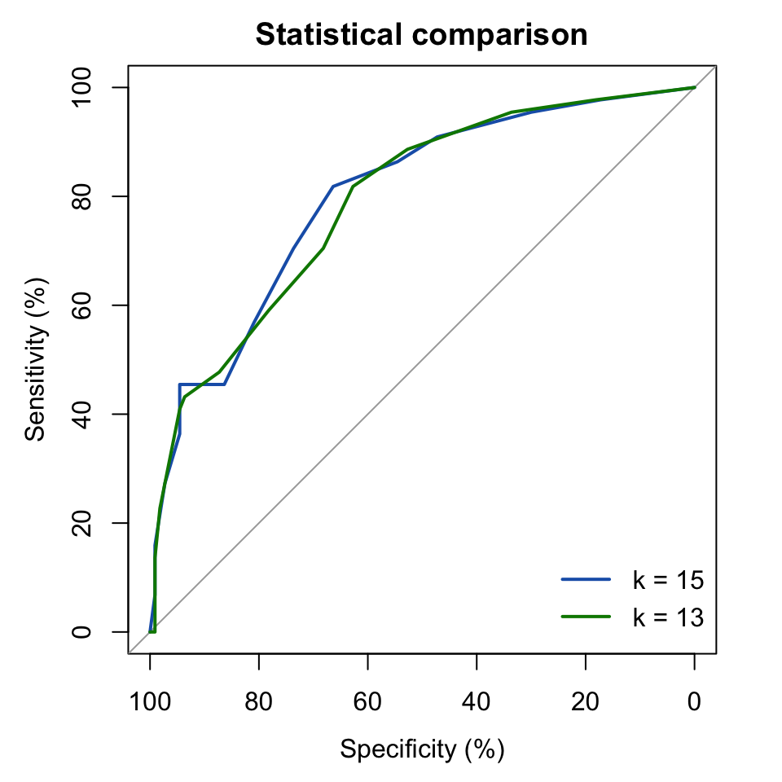

```r
knn.prob.cv <- predict(knn.mod.cv, newdata = testing, type = "prob")
knn.prob.boot <- predict(knn.mod.boot, newdata = testing, type = "prob")

roc.knn.cv <- plot.roc(testing$diabetes, knn.prob.cv[, 2],
                       percent = TRUE, col = "#1c61b6",
                       main = "Statistical comparison")

roc.knn.boot <- lines.roc(testing$diabetes, knn.prob.boot[, 2],
                          percent = TRUE, col = "#008600")

legend("bottomright", legend = paste("k =", c(k.optim.cv, k.optim.boot)),
       col = c("#1c61b6", "#008600"), lwd = 2, bty = 'n')
```

- Full AUC

```r
auc(roc.knn.cv)
```

```
Area under the curve: 79.8%
```

```r
auc(roc.knn.boot)
```

```
Area under the curve: 79.1%
```

- Partial AUC

```r
auc(roc.knn.cv, partial.auc = c(100, 80),
    partial.auc.focus = "specificity", partial.auc.correct = TRUE)
```

```
Corrected partial area under the curve (specificity 100%-80%): 67.6%
```

- ROC Curve with Partial AUC

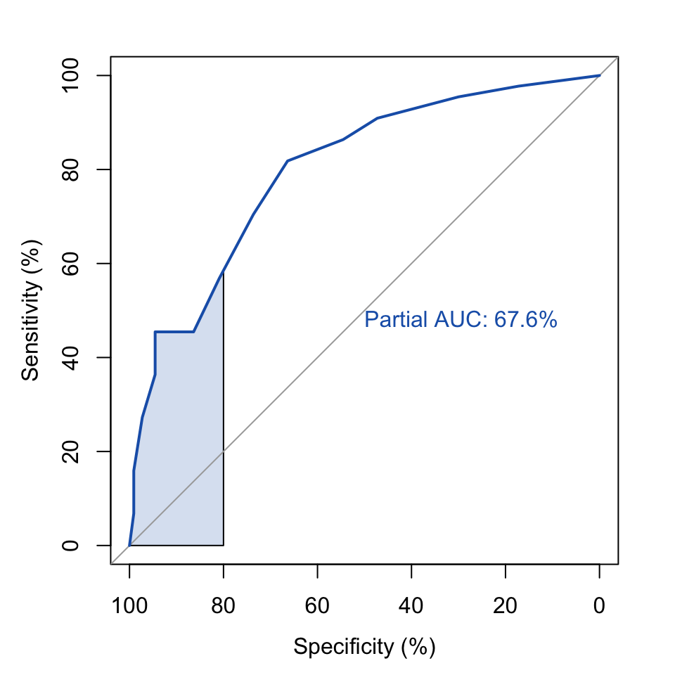

```r
plot.roc(testing$diabetes, knn.prob.cv[, 2], col = "#1c61b6",
         percent = TRUE, partial.auc = c(100, 80),
         partial.auc.correct = TRUE, print.auc = TRUE,
         auc.polygon = TRUE, auc.polygon.col = "#1c61b630")
```

- Other available arguments: Check `?plot.roc`
- More example: https://xrobin.github.io/pROC/screenshots.html